# TRABAJO INDIVIDUAL TD

Laura Carrasco Sánchez

2025-10-20

## PROBLEMA 1:

Una empresa de ropa sevillana debe decidir donde comenzar a expandir su negocio en otras cuidades.

Las alternativas son:

$$\begin{array}{l}
A_1: \text{Cáceres} \\
A_2: \text{Madrid} \\
A_3: \text{Cádiz}
\end{array}$$

El éxito depende del comportamiento del mercado en estas zonas. Pueden considerarse tres situaciones:

$$\begin{array}{l}
S_1: \text{Baja demanda} \\
S_2: \text{Demanda media} \\
S_3: \text{Alta demanda}
\end{array}$$

Los beneficios esperados se esperan en la siguiente tabla en miles de €:

```r
tb1<- crea.tablaX(c(30,70,90, 50,80,60, 90,40,20), numalternativas = 3, numestados = 3, nb_alternativas = c("Cáceres", "Madrid", "Cádiz"), nb_estados=c("baja_demanda", "demanda_media", "alta_demanda"))
tb1
```

```
##         baja_demanda demanda_media alta_demanda
## Cáceres           30            70           90
## Madrid            50            80           60
## Cádiz             90            40           20
```

Los costes esperados se muestran en la siguiente tabla en miles de €:

```r
tb12<- crea.tablaX(c(90,50,30, 80,40,60, 20,70,90), numalternativas = 3, nb_alternativas = c("Cáceres", "Madrid", "Cádiz"), nb_estados=c("baja_demanda", "demanda_media", "alta_demanda"))
tb12
```

```
##         baja_demanda demanda_media alta_demanda
## Cáceres           90            50           30
## Madrid            80            40           60
## Cádiz             20            70           90
```

*FAVORABLE*

```r
criterio.Wald(tb1, favorable = TRUE)
```

```
## $criterio
## [1] "Wald"
##
## $metodo
## [1] "favorable"
##
## $tablaX
##         baja_demanda demanda_media alta_demanda
## Cáceres           30            70           90
## Madrid            50            80           60
## Cádiz             90            40           20
##
## $ValorAlternativas
## Cáceres  Madrid   Cádiz
##      30      50      20
##
## $ValorOptimo
## [1] 50
##
## $AlternativaOptima
## Madrid
##      2
```

Según el criterio de Wald, lo mejor es seleccionar la alternativa 2, es decir, poner la nueva tienda en Madrid.

```r
criterio.Optimista(tb1, favorable = TRUE)
```

```
## $criterio
## [1] "Optimista"
##
## $metodo
## [1] "favorable"
##
## $tablaX
##         baja_demanda demanda_media alta_demanda
## Cáceres           30            70           90
## Madrid            50            80           60
## Cádiz             90            40           20
##
## $ValorAlternativas
## Cáceres  Madrid   Cádiz
##      90      80      90
##
## $ValorOptimo
## [1] 90
##
## $AlternativaOptima
## Cáceres   Cádiz
##       1       3
```

Según el criterio Optimista tenemos dos posibles soluciones óptimas, la alternativa 1 y la 3, es decir, poner la nueva tienda en Cáceres y en Cádiz.

para alfa=0.5

```r
criterio.Hurwicz(tb1, alfa = 0.5, favorable = TRUE)
```

```
## $criterio
## [1] "Hurwicz"
##
## $alfa
## [1] 0.5
##
## $metodo
## [1] "favorable"
##
## $tablaX
##         baja_demanda demanda_media alta_demanda
## Cáceres           30            70           90
## Madrid            50            80           60
## Cádiz             90            40           20
##
## $ValorAlternativas
## Cáceres  Madrid   Cádiz
##      60      65      55
##
## $ValorOptimo
## [1] 65
##
## $AlternativaOptima
## Madrid
##      2
```

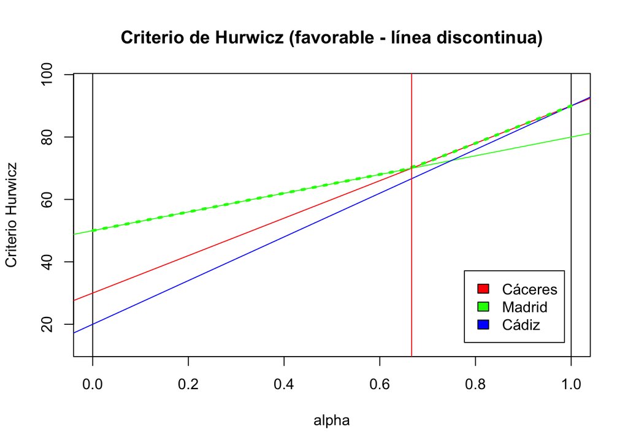

```
## $AltOptimas
## [1] 2 1
##
## $PuntosDeCorte
## [1] 0.667
##
## $IntervalosAlfa
##      Intervalo       Alternativa
## [1,] "( 0 , 0.667 )" "2"
## [2,] "( 0.667 , 1 )" "1"
```

```r
dibuja.criterio.Hurwicz_Intervalos(tb1, favorable = TRUE, T)
```

Según el criterio de Hurwicz, para un valor de alfa entre 0 y 0.667 la mejor alternativa es la 2 (poner la nueva tienda en Madrid), y para alfa entre 0.667 y 1 la mejor alternativa es la 1 (poner la nueva tienda en Cáceres).

```r
criterio.Savage(tb1, favorable = TRUE)
```

```
## $criterio
## [1] "Savage"
##
## $metodo
## [1] "favorable"
##
## $tablaX
##         baja_demanda demanda_media alta_demanda
## Cáceres           30            70           90
## Madrid            50            80           60
## Cádiz             90            40           20
##
## $Mejores
##  baja_demanda demanda_media  alta_demanda
##            90            80            90
##
## $Pesos
##         baja_demanda demanda_media alta_demanda
## Cáceres           60            10            0
## Madrid            40             0           30
## Cádiz              0            40           70
##
## $ValorAlternativas
## Cáceres  Madrid   Cádiz
##      60      40      70
##
## $ValorOptimo
## [1] 40
##
## $AlternativaOptima
## Madrid
##      2
```

Según el criterio de Savage la alternativa optina es la segunda, es decir, poner la nueva tienda en Madrid.

```r
criterio.PuntoIdeal(tb1, favorable = TRUE)
```

```
## $criterio
## [1] "Punto Ideal"
##
## $metodo
## [1] "favorable"
##
## $tablaX
##         baja_demanda demanda_media alta_demanda
## Cáceres           30            70           90
## Madrid            50            80           60
## Cádiz             90            40           20
##
## $Mejores
##  baja_demanda demanda_media  alta_demanda
##            90            80            90
##
## $ValorAlternativas
##  Cáceres   Madrid    Cádiz
## 60.82763 50.00000 80.62258
##
## $ValorOptimo
## [1] 50
##
## $AlternativaOptima
## Madrid
##      2
```

Según el criterio PuntoIdeal la mejor opción es la alternativa 2, es decir, poner la nueva tienda en Madrid.

```r
criterio.Laplace(tb1, favorable =T)
```

```
## $criterio
## [1] "Laplace"
##
## $metodo
## [1] "favorable"
##
## $tablaX
##         baja_demanda demanda_media alta_demanda
## Cáceres           30            70           90
## Madrid            50            80           60
## Cádiz             90            40           20
##
## $ValorAlternativas
##  Cáceres   Madrid    Cádiz
## 63.33333 63.33333 50.00000
##
## $ValorOptimo
## [1] 63.33333
##
## $AlternativaOptima
## Cáceres  Madrid
##       1       2
```

Según el criterio de Laplace tenemos dos posibles soluciones óptimas, la alternativa 1 y la 2, es decir, poner la nueva tienda en Cáceres y en Madrid.

*DESFAVORABLE*

```r
criterio.Wald(tb12, favorable = F)
```

```
## $criterio
## [1] "Wald"
##
## $metodo
## [1] "desfavorable"
##
## $tablaX
##         baja_demanda demanda_media alta_demanda
## Cáceres           90            50           30
## Madrid            80            40           60
## Cádiz             20            70           90
##
## $ValorAlternativas
## Cáceres  Madrid   Cádiz
##      90      80      90
##
## $ValorOptimo
## [1] 80
##
## $AlternativaOptima
## Madrid
##      2
```

Según el criterio de Wald la mejor opción es la alternativa dos, es decir, poner la nueva tienda en Madrid.

```r
criterio.Optimista(tb12, favorable = F)
```

```
## $criterio
## [1] "Optimista"
##
## $metodo
## [1] "desfavorable"
##
## $tablaX
##         baja_demanda demanda_media alta_demanda
## Cáceres           90            50           30
## Madrid            80            40           60
## Cádiz             20            70           90
##
## $ValorAlternativas
## Cáceres  Madrid   Cádiz
##      30      40      20
##
## $ValorOptimo
## [1] 20
##
## $AlternativaOptima
## Cádiz
##     3
```

Según el criterio de Optimista la mejor opción es la alternativa tres, es decir, poner la nueva tienda en Cádiz.

para alfa=0.5

```r
criterio.Hurwicz(tb12, alfa = 0.5, favorable = F)
```

```
## $criterio
## [1] "Hurwicz"
##
## $alfa
## [1] 0.5
##
## $metodo
## [1] "desfavorable"
##
## $tablaX
##         baja_demanda demanda_media alta_demanda
## Cáceres           90            50           30
## Madrid            80            40           60
## Cádiz             20            70           90
##
## $ValorAlternativas
## Cáceres  Madrid   Cádiz
##      60      60      55
##
## $ValorOptimo
## [1] 55
##
## $AlternativaOptima
## Cádiz
##     3
```

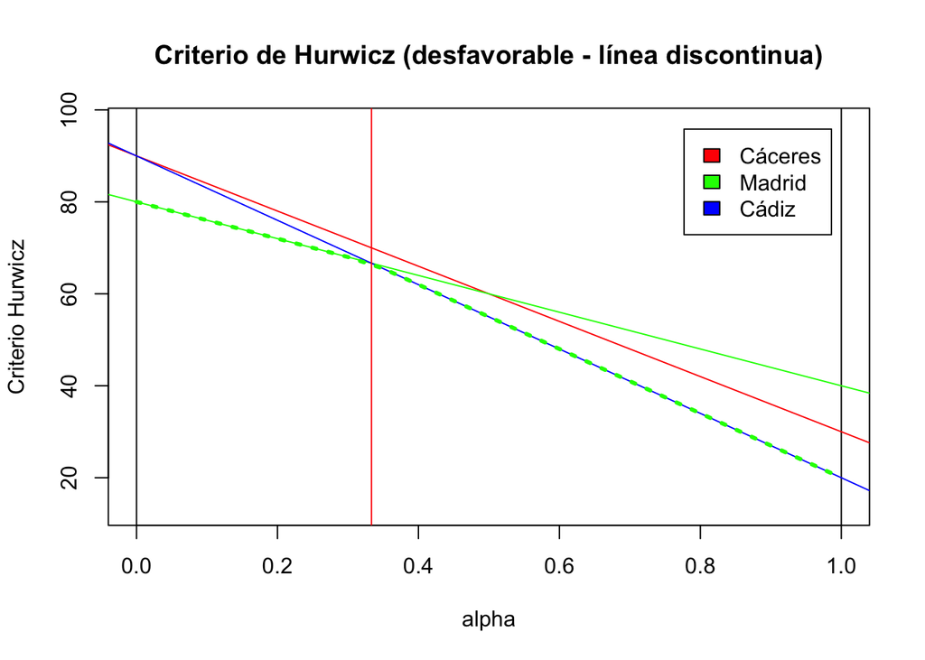

```
## $AltOptimas
## [1] 2 3
##
## $PuntosDeCorte
## [1] 0.333
##
## $IntervalosAlfa
##      Intervalo       Alternativa
## [1,] "( 0 , 0.333 )" "2"
## [2,] "( 0.333 , 1 )" "3"
```

```r
dibuja.criterio.Hurwicz_Intervalos(tb12, favorable = F, T)
```

Según el criterio de Hurwicz, para un valor de alfa entre 0 y 0.333 la mejor alternativa es la 2 (poner la nueva tienda en Madrid), y para alfa entre 0.333 y 1 la mejor alternativa es la 3 (poner la nueva tienda en Cádiz).

```r
criterio.Savage(tb12, favorable = F)
```

```
## $criterio
## [1] "Savage"
##
## $metodo
## [1] "desfavorable"
##
## $tablaX
##         baja_demanda demanda_media alta_demanda
## Cáceres           90            50           30
## Madrid            80            40           60
## Cádiz             20            70           90
##
## $Mejores
##  baja_demanda demanda_media  alta_demanda
##            20            40            30
##
## $Pesos
##         baja_demanda demanda_media alta_demanda
## Cáceres           70            10            0
## Madrid            60             0           30
## Cádiz              0            30           60
##
## $ValorAlternativas
## Cáceres  Madrid   Cádiz
##      70      60      60
##
## $ValorOptimo
## [1] 60
##
## $AlternativaOptima
## Madrid  Cádiz
##      2      3
```

Según el criterio de Savage tenemos dos posibles soluciones óptimas, la alternativa 2 y la 3, es decir, poner la nueva tienda en Madrid y en Cádiz.

```r
criterio.PuntoIdeal(tb12, favorable = F)
```

```
## $criterio
## [1] "Punto Ideal"
##
## $metodo
## [1] "desfavorable"
##
## $tablaX
##         baja_demanda demanda_media alta_demanda
## Cáceres           90            50           30
## Madrid            80            40           60
## Cádiz             20            70           90
##
## $Mejores
##  baja_demanda demanda_media  alta_demanda
##            20            40            30
##
## $ValorAlternativas
##  Cáceres   Madrid    Cádiz
## 70.71068 67.08204 67.08204
##
## $ValorOptimo
## [1] 67.08204
##
## $AlternativaOptima
## Madrid  Cádiz
##      2      3
```

Según el criterio punto ideal tenemos dos posibles soluciones óptimas, la alternativa 2 y la 3, es decir, poner la nueva tienda en Madrid y en Cádiz.

```r
criterio.Laplace(tb12, favorable =F)
```

```
## $criterio
## [1] "Laplace"
##
## $metodo
## [1] "desfavorable"
##
## $tablaX
##         baja_demanda demanda_media alta_demanda
## Cáceres           90            50           30
## Madrid            80            40           60
## Cádiz             20            70           90
##
## $ValorAlternativas
##  Cáceres   Madrid    Cádiz
## 56.66667 60.00000 60.00000
##
## $ValorOptimo
## [1] 56.66667
##
## $AlternativaOptima
## Cáceres
##       1
```

Según el criterio de Laplace la mejor opción es la alternativa uno, es decir, poner la nueva tienda en Cáceres.

## PROBLEMA 2:

En una cuidad se está planteando restringir el uso de coches en el centro de esta para reducir las emisiones contaminantes. Las autoridades deben decidir qué vehículos podrán acceder a la zona restringida.

Tenemos tres alternativas sobre a que vehículos permitir el acceso:

$$\begin{array}{l}
A_1: \text{Sólo residentes de la zona} \\
A_2: \text{Sólo coches eléctricos} \\
A_3: \text{Todos los coches}
\end{array}$$

La decisión dependerá de las condiciones de los tipos de coches, representadas por tres posibles estados de la naturaleza:

$$\begin{array}{l}
S_1: \text{Año de fabricación} \\
S_2: \text{Tipo de combustible} \\
S_3: \text{Nivel de emisiones medio}
\end{array}$$

Los costes asociados (en miles de euros) representan el gasto que tendría el ayuntamiento en medidas complementarias (control, señalizacion, mantenimiento) según la alternativa elegida y el entorno.

```r
tb2<- crea.tablaX(c(500,700,800, 900,600,400, 300,800,1000), numalternativas = 3, nb_alternativas = c("solo_residentes", "solo_eléctricos", "todos"), nb_estados = c("año_fabricación", "tipo_combustible", "nivel_emisiones"))
tb2
```

```
##                 año_fabricación tipo_combustible nivel_emisiones
## solo_residentes             500              700             800
## solo_eléctricos             900              600             400
## todos                       300              800            1000
```

para alfa=0.5

```r
criterio.Todos(tb2, alfa=0.5, favorable = F)
```

```
##                    año_fabricación tipo_combustible nivel_emisiones
## solo_residentes                500              700             800
## solo_eléctricos                900              600             400
## todos                          300              800            1000
## iAlt.Opt (Desfav.)              --               --              --
##                               Wald Optimista
## solo_residentes                800       500
## solo_eléctricos                900       400
## todos                         1000       300
## iAlt.Opt (Desfav.) solo_residentes     todos
##                                                  Hurwicz          Savage
## solo_residentes                                      650             400
## solo_eléctricos                                      650             600
## todos                                                650             600
## iAlt.Opt (Desfav.) solo_residentes,solo_eléctricos,todos solo_residentes
##                            Laplace     Punto Ideal    Veces Optima
## solo_residentes              666.7           458.3               4
## solo_eléctricos              633.3           600.0               2
## todos                        700.0           632.5               2
## iAlt.Opt (Desfav.) solo_eléctricos solo_residentes solo_residentes
```

Aplicando todos los criterios a nuestro problema consideramos que la alternativa 1 (permitir acceso a la zona restringida sólo a los residentes de esta) es 4 veces óptima, la alternativa 2 (permitir acceso sólo a coche eléctricos) es 2 veces óptima y la alternativa 3 (permitir acceso a todos los coches) es 2 veces óptima. Por tanto, la mejor alternativa es la 1, al ser la que se ha elegido en más criterios en comparación a las demás.